# 用户聚类分析

Qi Zou

2017-08-31

# 简介

本次报告的目的的在于将`流失用户`建立画像，并对其进行聚类，分析并命名类别，以便对应业务上的策略。

# 数据汇总

## 字段列表

本次使用的字段如下

| Variable Name | Description |
| --- | --- |
| uid | uid |
| filtered_atten_num | 关注个数 |
| filtered_fans_num | 粉丝个数 |
| filtered_recip_num | 互粉个数 |
| del_atten_cnt | 取关个数 |
| gender | 性别 |
| age | 年龄（0为为取到数据） |
| regprov_name | 注册省份 |
| regcity_name | 注册城市 |
| v_vip_level | vip等级 |
| v_vuser_type_id | vip类别 |
| v_is_famous | 是否名人 |
| member_level | 会员等级 |
| member_pay_type | 付费方式 |
| member_status | 会员状态 |
| reg_days | 注册日期 |
| reg_class_id | 注册类别id |
| reg_src | 注册来源 |
| days_in_a_month | 过去30天活跃天数 |
| pub_cnt | 发博量 |
| tran_cnt | 转发数量 |
| traned_cnt_total | 被动转发数量 |
| cmt_cnt_total | 评论数量 |
| cmted_cnt | 被评论数量 |
| clcted_cnt | 被收藏数量 |
| publog_at_cnt | 博文提及次数 |
| pubblog_ated_cnt | 博文被提及次数 |
| cmt_at_cnt | 评论提及次数’ |
| cmt_ated_cnt | 评论被提及次数 |
| expo_hot_times | 热门刷新次数 |
| expo_hot_cnt | 热门曝光条数 |

## 抽样

本次使用的样本为20170724当日登录用户的7日内流失用户。

| Var2 | Freq |
| --- | --- |
| filtered_atten_num | Min. : 0.0 |
| filtered_atten_num | 1st Qu.: 34.0 |
| filtered_atten_num | Median : 62.0 |
| filtered_atten_num | Mean : 103.4 |
| filtered_atten_num | 3rd Qu.: 107.0 |
| filtered_atten_num | Max. :108085.0 |
| filtered_atten_num | NA's :36158 |
| filtered_fans_num | Min. : 0 |
| filtered_fans_num | 1st Qu.: 5 |
| filtered_fans_num | Median : 23 |

[output cut: 200 more lines]

# 特征选择

由于类别字段以及大长尾字段对聚类算法贡献小且造成很大干扰，我们字段进行过滤，进入模型的字段如下。

```
## [1] "uid"                "filtered_atten_num" "filtered_fans_num"
## [4] "age"                "reg_days"           "days_in_a_month"
## [7] "expo_hot_times"     "expo_hot_cnt"
```

# 流失用户聚类

为了计算的时效性，我们对现有数据进行抽样，样本量为1000，然后对其样本进行EM聚类分析。

[interactive chart not shown]

# 类别的划分

通过观察类别的字段分布，定义其类别的业务含义。

| group | filtered_atten_num | filtered_fans_num | age | reg_days | days_in_a_month | expo_hot_cnt | g.expo_hot_times | n |
| --- | --- | --- | --- | --- | --- | --- | --- | --- |
| 1 | 279 | 129 | 23 | 1500 | 14 | 573 | 41 | 39 |
| 2 | 43 | 27.5 | 20 | 743 | 8 | 129 | 7 | 254 |
| 3 | 93.5 | 29 | 22 | 852.5 | 16 | 456 | 26 | 160 |
| 4 | 58 | 1 | 0 | 23.5 | 5 | 98.5 | 6 | 144 |
| 5 | 61 | 14 | 21 | 705 | 3 | 31 | 2 | 275 |
| 6 | 215 | 131.5 | 27 | 2175.5 | 6 | 42.5 | 3 | 120 |
| 7 | 258 | 2205 | 27 | 1997.5 | 18 | 2751.5 | 173 | 8 |

上表显示的数值为media中位数，由于样本分布原因，极致会对平均值产生过大影响，故采用中位数。

## 关联所有字段

接下来我们连接所有字段，观察其类别的分布情况。

### group 1

| Var2 | Freq |
| --- | --- |
| uid | 662001 : 1 |
| uid | 1271529110: 1 |
| uid | 1610280131: 1 |
| uid | 1794537874: 1 |
| uid | 1822986255: 1 |
| uid | 1858980872: 1 |
| uid | (Other) :33 |
| filtered_atten_num | Min. : 24.0 |
| filtered_atten_num | 1st Qu.: 99.5 |
| filtered_atten_num | Median : 279.0 |

[output cut: 214 more lines]

### group 2

| Var2 | Freq |
| --- | --- |
| uid | 1008584907: 1 |
| uid | 1025858880: 1 |
| uid | 1031212965: 1 |
| uid | 1235449405: 1 |
| uid | 1642926081: 1 |
| uid | 1790140457: 1 |
| uid | (Other) :248 |
| filtered_atten_num | Min. : 0.00 |
| filtered_atten_num | 1st Qu.: 21.00 |
| filtered_atten_num | Median : 43.00 |

[output cut: 214 more lines]

### group 3

| Var2 | Freq |
| --- | --- |
| uid | 1005583855: 1 |
| uid | 1025383255: 1 |
| uid | 1419539815: 1 |
| uid | 1488772880: 1 |
| uid | 1596948260: 1 |
| uid | 1615520763: 1 |
| uid | (Other) :154 |
| filtered_atten_num | Min. : 1.00 |
| filtered_atten_num | 1st Qu.: 42.75 |
| filtered_atten_num | Median : 93.50 |

[output cut: 214 more lines]

### group 4

| Var2 | Freq |
| --- | --- |
| uid | 6148196370: 1 |
| uid | 6148567166: 1 |
| uid | 6164094436: 1 |
| uid | 6166892511: 1 |
| uid | 6174266765: 1 |
| uid | 6178062471: 1 |
| uid | (Other) :138 |
| filtered_atten_num | Min. : 0.00 |
| filtered_atten_num | 1st Qu.: 16.00 |
| filtered_atten_num | Median : 58.00 |

[output cut: 214 more lines]

### group 5

| Var2 | Freq |
| --- | --- |
| uid | 1005151311: 1 |
| uid | 1250491063: 1 |
| uid | 1404967094: 1 |
| uid | 1622153197: 1 |
| uid | 1764088244: 1 |
| uid | 1802002530: 1 |
| uid | (Other) :269 |
| filtered_atten_num | Min. : 0.00 |
| filtered_atten_num | 1st Qu.: 31.50 |
| filtered_atten_num | Median : 61.00 |

[output cut: 214 more lines]

### group 6

| Var2 | Freq |
| --- | --- |
| uid | 1007899463: 1 |
| uid | 1098881673: 1 |
| uid | 1109781354: 1 |
| uid | 1195069024: 1 |
| uid | 1373852587: 1 |
| uid | 1395137197: 1 |
| uid | (Other) :114 |
| filtered_atten_num | Min. : 14.0 |
| filtered_atten_num | 1st Qu.:125.5 |
| filtered_atten_num | Median :215.0 |

[output cut: 214 more lines]

### group 7

| Var2 | Freq |
| --- | --- |
| uid | 1627778307:1 |
| uid | 1766581032:1 |
| uid | 1913903095:1 |
| uid | 2079571013:1 |
| uid | 2593128110:1 |
| uid | 2691900233:1 |
| uid | (Other) :2 |
| filtered_atten_num | Min. : 41.0 |
| filtered_atten_num | 1st Qu.: 138.8 |
| filtered_atten_num | Median : 258.0 |

[output cut: 214 more lines]

# 增加样本量

接下来我们将样本量增加到5000。

[interactive chart not shown]

| group | filtered_atten_num | filtered_fans_num | age | reg_days | days_in_a_month | expo_hot_cnt | g.expo_hot_times | n |
| --- | --- | --- | --- | --- | --- | --- | --- | --- |
| 1 | 153 | 80 | 26 | 1832 | 7 | 83 | 5 | 900 |
| 2 | 52 | 19 | 20 | 696 | 13 | 292 | 17 | 1113 |
| 3 | 233 | 91 | 23 | 1685 | 14 | 571 | 36 | 317 |
| 4 | 54 | 26 | 21 | 696 | 4 | 41 | 2 | 1711 |
| 5 | 59 | 4 | 0 | 79 | 6 | 101 | 6 | 550 |
| 6 | 55 | 0 | 0 | 10 | 3 | 50 | 3 | 353 |
| 7 | 424 | 1110 | 25 | 1990 | 9 | 72 | 4 | 56 |

## 关联所有字段

| group | Var2 | Freq |
| --- | --- | --- |
| 1 | uid | 1018346094: 1 |
| 1 | uid | 1019695442: 1 |
| 1 | uid | 1032033047: 1 |
| 1 | uid | 1034164931: 1 |
| 1 | uid | 1040144970: 1 |
| 1 | uid | 1055761597: 1 |
| 1 | uid | (Other) :894 |
| 1 | filtered_atten_num | Min. : 0.0 |
| 1 | filtered_atten_num | 1st Qu.: 97.0 |
| 1 | filtered_atten_num | Median :153.0 |

[output cut: 1558 more lines]

# 留存用户

接下来我们对比留存用户在选用特征上与流失用户的区别。

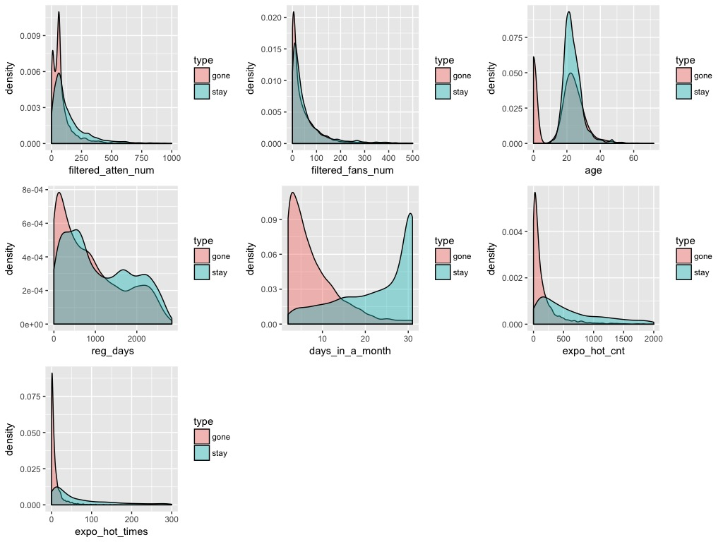

# 留存用户聚类

[interactive chart not shown]

通过上图可以看到，5类标识已经可清晰的将留存用户进行划分。

| group | filtered_atten_num | filtered_fans_num | age | reg_days | days_in_a_month | expo_hot_cnt | expo_hot_times | n |
| --- | --- | --- | --- | --- | --- | --- | --- | --- |
| 1 | 58 | 3 | 0 | 89 | 11 | 205 | 13 | 237 |
| 2 | 168.5 | 60.5 | 22 | 1481 | 30 | 2619 | 182.5 | 900 |
| 3 | 157 | 69 | 22 | 1495 | 31 | 10467 | 621 | 309 |
| 4 | 144 | 44 | 26 | 1753.5 | 22 | 435.5 | 28 | 548 |
| 5 | 67 | 21 | 20 | 576 | 21 | 458 | 28 | 1006 |